# Introduction

This notebook presents **DCGAN** architecture trained on [SVHN](http://ufldl.stanford.edu/housenumbers/) and [CelebA](http://mmlab.ie.cuhk.edu.hk/projects/CelebA.html) datasets.

Depending on which dataset you want to use comment out cells for the other one. There is no need to change DCGAN code, it will work with both datasets.

**Contents**

- SVHN Dataset
- CelebA Dataset
- DCGAN

**References**

- [Unsupervised Representation Learning with Deep Convolutional Generative Adversarial Networks](https://arxiv.org/abs/1511.06434) (2015) by Alec Radford, Luke Metz, Soumith Chintala

# Imports

```python
import os
import time
import numpy as np
import matplotlib.pyplot as plt
```

```python
import torch
import torch.nn as nn
import torch.optim as optim
```

```python
device = torch.device("cuda:0" if torch.cuda.is_available() else "cpu")
```

# SVHN Dataset

```python
# from torchvision import datasets
```

Download dataset

```python
# dataset = datasets.SVHN(root='~/.pytorch/svhn/', split='train', download=True, transform=None)
```

Because this is very small dataset we will load it fully into GPU. Otherwise dataloader will slow learning considerably.

```python
# x_train = (dataset.data.astype(np.float32) / 127.5) - 1   # scale to range [-1..1]
# x_train = x_train[:-41]  # make divisible by 512
# print(x_train.shape)
```

Visualize the data

```python
# fig, axes = plt.subplots(nrows=1, ncols=8, figsize=[16,6])
# for i in range(len(axes)):
#     idx = np.random.randint(0, len(x_train))
#     img = x_train[idx]
#     img = img/2 + .5         # -1..1 -> 0..1
#     img = img.transpose(1, 2, 0)
#     axes[i].imshow(img); axes[i].axis('off')
```

Move to GPU if available

```python
# x_train = torch.tensor(x_train, device=device)
```

# CelebA Dataset

Point this to folder with CelebA unzipped

```python
dataset_location = '/home/marcin/Datasets/img_align_celeba'
```

```python
datafile = os.path.join(dataset_location, 'img_align_celeba_32x32.npz')
print(datafile)
```

```
/home/marcin/Datasets/img_align_celeba/img_align_celeba_32x32.npz
```

```python
import PIL
```

Get names of all images in CelebA data folder

```python
all_files = os.listdir(os.path.join(dataset_location, 'img_align_celeba'))
```

Images in CelebA are pre-aligned such that eyes and mouth location on different images is almost identical. We will use this fact and hardcode cropping to 128x128 and rescale to 32x32

```python
def crop_celeba(img, size):
    assert img.size == (178, 218)
    box = [25, 65, img.width-25, img.height-25]  # crop 25/65/25/25 from left/top/right/bottom
    return img.crop(box)                         # result.size = (128, 128)
```

Show couple images with and without cropping

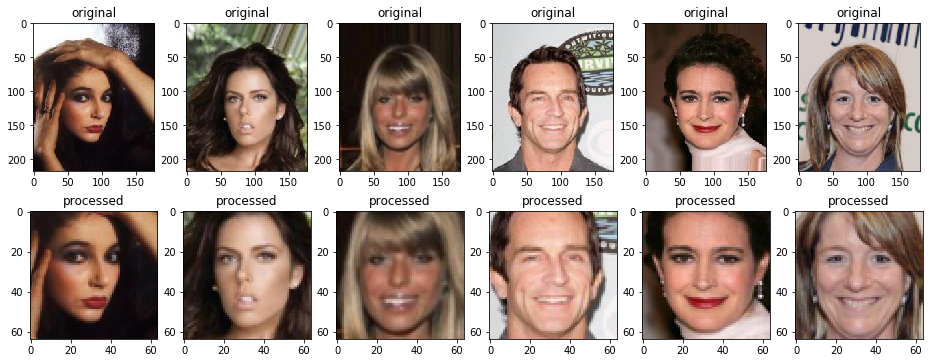

```python
fig, (axes1, axes2) = plt.subplots(nrows=2, ncols=6, figsize=[16,6])
for i in range(len(axes1)):
    idx = i  # np.random.randint(0, len(all_files))
    img_full_path = os.path.join(dataset_location, 'img_align_celeba', all_files[idx])
    img = PIL.Image.open(img_full_path)
    img_128x128 = crop_celeba(img, None)
    img_64x64 = img_128x128.resize([64, 64], PIL.Image.BICUBIC)
    axes1[i].imshow(img)
    axes1[i].set_title('original')
    axes2[i].imshow(img_64x64)
    axes2[i].set_title('processed')
```

This function will read, crop, scale all images and put them into one large numpy array

```python
def load_all_images(dataset_location, all_files, size=32):
    all_images = []
    for i in range(len(all_files)):
        img_full_path = os.path.join(dataset_location, 'img_align_celeba', all_files[i])
        img = PIL.Image.open(img_full_path)
        img_128x128 = crop_celeba(img, None)
        img_small = img_128x128.resize([size, size], PIL.Image.BICUBIC)
        arr = np.array(img_small)
        assert arr.shape == (size, size, 3)
        all_images.append(arr)
        if i % 10000 == 0:
            print(f'Image {i} of {len(all_files)}')
    return np.array(all_images)
```

Check if dataset was processed earlier, if not then process and save to .npz, if yes then just load from file

```python
if not os.path.isfile(datafile):
    print('Creating datafile...')
    all_images = load_all_images(dataset_location, all_files, size=32)
    np.savez(datafile, all_images=all_images)
else:
    print('Loading from file...')
    npzfile = np.load(datafile)
    all_images = npzfile['all_images']
```

```
Loading from file...
```

Convert to float32, scale to -1..1 range and re-order dimensions to match pytorch convention

```python
x_train = (all_images.astype(np.float32) / 127.5) - 1      # scale to range [-1..1]
x_train = x_train.transpose(0, 3, 1, 2)                    # pytorch ordering NCHW
x_train = x_train[:-103]                                   # make divisible by 128
x_train.shape
```

```
(202496, 3, 32, 32)
```

```python
del all_images  # save memory
```

Move everything to GPU if available (approx 2.5GB)

```python
x_train = torch.tensor(x_train, device=device)
```

# DCGAN

Discriminator

```python
class Discriminator(nn.Module):
    def __init__(self, conv_dim=32):
        super(Discriminator, self).__init__()

        self.L1_conv = nn.Conv2d(3, conv_dim, kernel_size=4, stride=2, padding=1, bias=False)
        self.L1_act = nn.LeakyReLU(0.2)

        self.L2_conv = nn.Conv2d(conv_dim, 2*conv_dim, kernel_size=4, stride=2, padding=1, bias=False)
        self.L2_bn = nn.BatchNorm2d(2*conv_dim)
        self.L2_act = nn.LeakyReLU(0.2)

        self.L3_conv = nn.Conv2d(2*conv_dim, 4*conv_dim, kernel_size=4, stride=2, padding=1, bias=False)
        self.L3_bn = nn.BatchNorm2d(4*conv_dim)
        self.L3_act = nn.LeakyReLU(0.2)

        self.L4_fc = nn.Linear(in_features=4*conv_dim*4*4, out_features=1)

    def forward(self, x):
        x = self.L1_conv(x)
        x = self.L1_act(x)

        x = self.L2_conv(x)
        x = self.L2_bn(x)
        x = self.L2_act(x)

        x = self.L3_conv(x)
        x = self.L3_bn(x)
        x = self.L3_act(x)

        x = x.view(x.size(0), -1)  # flatten
        x = self.L4_fc(x)
        return x                   # return logits
```

Generator

```python
class Generator(nn.Module):
    def __init__(self, z_size, conv_dim=32):
        super(Generator, self).__init__()
        self.conv_dim = conv_dim

        self.L0_fc = nn.Linear(in_features=z_size, out_features=4*conv_dim*4*4)

        self.L1_convT = nn.ConvTranspose2d(4*conv_dim, 2*conv_dim, kernel_size=4, stride=2, padding=1, bias=False)
        self.L1_bn = nn.BatchNorm2d(2*conv_dim)
        self.L1_act = nn.ReLU()

        self.L2_convT = nn.ConvTranspose2d(2*conv_dim, conv_dim, kernel_size=4, stride=2, padding=1, bias=False)
        self.L2_bn = nn.BatchNorm2d(conv_dim)
        self.L2_act = nn.ReLU()

        self.L3_convT = nn.ConvTranspose2d(conv_dim, 3, kernel_size=4, stride=2, padding=1, bias=False)
        self.L3_act = nn.Tanh()

    def forward(self, x):
        x = self.L0_fc(x)
        x = x.view(x.size(0), 4*self.conv_dim, 4, 4)

        x = self.L1_convT(x)
        x = self.L1_bn(x)
        x = self.L1_act(x)

        x = self.L2_convT(x)
        x = self.L2_bn(x)
        x = self.L2_act(x)

        x = self.L3_convT(x)
        x = self.L3_act(x)
        return x                # image pixels in range -1..1
```

Build models, loss and optimizers

```python
conv_dim = 32
z_size = 100

generator = Generator(z_size=z_size, conv_dim=conv_dim)
discriminator = Discriminator(conv_dim)

generator.to(device)
discriminator.to(device)

criterion = nn.BCEWithLogitsLoss()

lr, betas = 0.0002, (0.5, 0.999)
d_optimizer = optim.Adam(discriminator.parameters(), lr, betas)
g_optimizer = optim.Adam(generator.parameters(), lr, betas)
```

Helpers

```python
def plot_images(x_fake):  # Expects tensor shape [batch, 3, width, height]
    fig, axes = plt.subplots(nrows=1, ncols=10, figsize=[16,9])
    for i, ax in enumerate(axes):
        img = x_fake[i].detach().cpu().permute(1, 2, 0).numpy()
        ax.imshow(img/2+.5)
        ax.axis('off')
    plt.show()

def plot_loss(losses):
    fig, ax = plt.subplots(nrows=1, ncols=1)
    ax.plot(losses['disc'], label='disc')
    ax.plot(losses['gen'], label='gen')
    plt.show()
```

Few more hyperparameters. `fixed_noise` is used to generate consistent sample images every epoch

```python
n_batch = 128
n_epochs = 1     # even 1 epoch will show some face-ish results, recommended 10-100 train epochs

fixed_noise = torch.rand(16, z_size, device=device)*2-1   # uniform -1..1
```

Train the model

```
Epoch ( 0.0s:   0     gloss: 0.95     dloss: 1.34
```

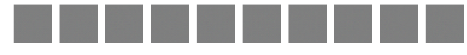

```
Epoch ( 1.9s:   0     gloss: 3.77     dloss: 0.40
```

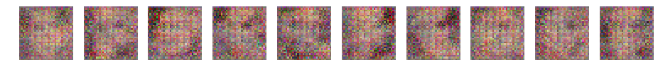

```
Epoch ( 3.7s:   0     gloss: 2.11     dloss: 0.60
```

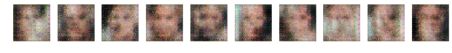

```
Epoch ( 5.6s:   0     gloss: 2.21     dloss: 0.71
```

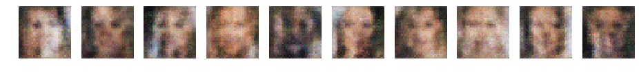

```
Epoch ( 7.5s:   0     gloss: 2.36     dloss: 0.77
```

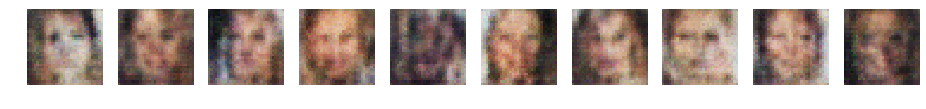

```
Epoch ( 9.3s:   0     gloss: 1.50     dloss: 0.85
```

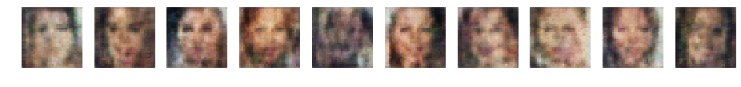

```
Epoch (11.1s:   0     gloss: 2.08     dloss: 0.82
```

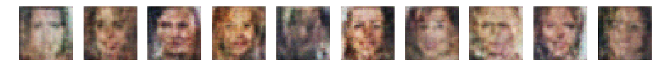

```
Epoch (12.9s:   0     gloss: 1.59     dloss: 0.91
```

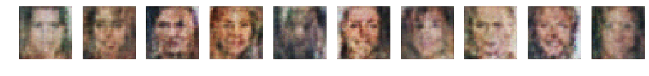

```
Epoch (14.8s:   0     gloss: 1.99     dloss: 0.97
```

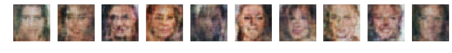

```
Epoch (16.5s:   0     gloss: 1.54     dloss: 0.91
```

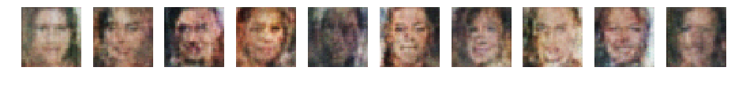

```
Epoch (18.3s:   0     gloss: 1.52     dloss: 0.83
```

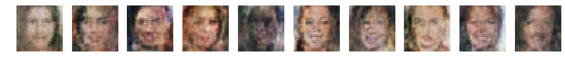

```
Epoch (20.2s:   0     gloss: 1.57     dloss: 1.00
```

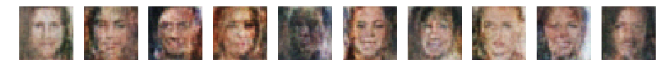

```
Epoch (22.0s:   0     gloss: 1.19     dloss: 0.96
```

[6 more figures not shown]

```python
losses = {'gen':[], 'disc':[]}
indices = np.array(range(len(x_train)))

iteration = 0
for e in range(n_epochs):

    time_start = time.time()

    np.random.shuffle(indices)
    for i in range(0, len(x_train), n_batch):

        # Pick next batch of real images
        i_batch = indices[i:i+n_batch]
        x_real = x_train[i_batch]

        # Generate fake images
        noise = torch.rand(len(x_real), z_size, device=device)*2-1  # uniform -1..1
        x_fake = generator(noise)


        # Train the discriminator
        d_optimizer.zero_grad()

        outputs_real = discriminator(x_real)  # logits
        y_real = torch.ones(len(x_real), 1, device=device) * .9
        d_real_loss = criterion(outputs_real, y_real)

        outputs_fake = discriminator(x_fake)  # logits
        y_fake = torch.zeros(len(x_fake), 1, device=device)
        d_fake_loss = criterion(outputs_fake, y_fake)

        d_loss = d_real_loss + d_fake_loss
        d_loss.backward()
        d_optimizer.step()


        # Train the generator
        g_optimizer.zero_grad()

        noise = torch.rand(len(x_real), z_size, device=device)*2-1  # uniform -1..1
        x_fake = generator(noise)
        y_fake = torch.ones(len(x_real), 1, device=device)   # flip labels
        outputs_fake = discriminator(x_fake)

        g_loss = criterion(outputs_fake, y_fake)
        g_loss.backward()
        g_optimizer.step()

        losses['disc'].append(d_loss.item())
        losses['gen'].append(g_loss.item())

        # Print some loss stats
        if iteration % 100 == 0:

            generator.eval()                   # switch batchnorm to eval mode
            samples = generator(fixed_noise)
            generator.train()

            time_epoch = time.time() - time_start
            print(f'Epoch ({time_epoch:4.1f}s): {e:3}     gloss: {g_loss:4.2f}     dloss: {d_loss:4.2f}')
            plot_images(samples)

        iteration += 1


    generator.eval()
    samples = generator(fixed_noise)
    generator.train()

    time_epoch = time.time() - time_start
    print(f'Epoch ({time_epoch:4.1f}s): {e:3}     gloss: {g_loss:4.2f}     dloss: {d_loss:4.2f}')
    plot_images(samples)
    plot_loss(losses)
```

# Debug code below this point

Code below is to help fix Keras DCGAN :(

```python
raise
```

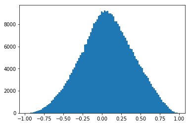

```python
plt.hist(x_fake.detach().cpu().numpy().ravel(), bins=100);
```

```python
generator.L0_fc.weight.detach().cpu().shape
```

[output not shown]

```
(100, 2048)
```

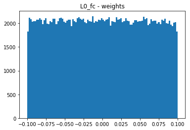

```python
p = generator.L0_fc.weight.detach().cpu().numpy().T
plt.hist(p.ravel(), bins=100)
plt.title('L0_fc - weights')
print(p.shape)
```

```
(2048,)
```

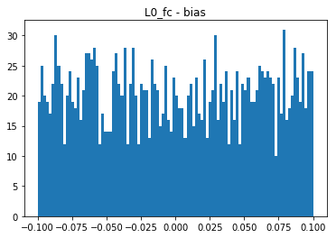

```python
p = generator.L0_fc.bias.detach().cpu().numpy().T
plt.hist(p.ravel(), bins=100);
plt.title('L0_fc - bias');
print(p.shape)
```

```
(4, 4, 64, 128)
```

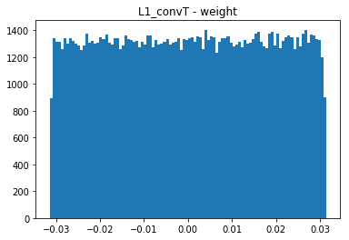

```python
p = generator.L1_convT.weight.detach().cpu().numpy().T
plt.hist(p.ravel(), bins=100);
plt.title('L1_convT - weight');
print(p.shape)
```

```python
generator.L1_bn
```

```
BatchNorm2d(64, eps=1e-05, momentum=0.1, affine=True, track_running_stats=True)
```

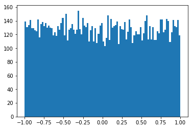

```python
plt.hist(noise.detach().cpu().numpy().ravel(), bins=100);
```